# PRACTICA 2: LIMPIEZA Y VALIDACIÓN DE LOS DATOS

Jose Ignacio Bengoechea Isasa

6 de enero 2018

Partimos de dos datasets, donde tenemos el total de minutos, partidos, puntos, rebotes, asistencias, tapones y robos efectuados por los jugadores de la NBA y las jugadores de la WNBA, que son la liga masuclina y femenina de baloncesto de Estados Unidos. Estos datos corresponden a la temporada 2016-17.

Nuestro objetivo es unificar estas fuentes en un unico dataset, limpiarlo, normalizarlo si es necesario, y establecer visualizaciones que nos permitan obtener información sobre la brecha salarial existente entre ambas ligas.

```r
# read data
nba_org <- read.csv("nba-stats_out.csv")
nba_org["sex"] <- NA
nba_org$sex<-0
wnba_org <- read.csv("wnba-stats_out.csv")
wnba_org["sex"] <- NA
wnba_org$sex<-1
t_nba <- rbind(nba_org, wnba_org)
n.var <- names(t_nba)
```

# 1 Limpieza de datos

El fichero de datos contiene 479 registros y 15 variables.

Contiene 314 jugadores y 165 jugadoras.

Las variables son player, games, minutes, points, rebds., assists, steals, blocks, salary, slry.pts., slry.rbds, slry.asts, slry.stls, slry.blks, sex.

## 1.1 Selección de datos

De estas variables nos interesa eliminar las siguientes, ya que son campos calculados:

- slry/pts. Es el resultado de salario/puntos.
- slry/rbds. Es el resultado de salario/rebotes.
- slry/asts. Es el resultado de salario/asistencias.
- slry/stls. Es el resultado de salario/robos.
- slry/blks. Es el resultado de salario/tapones.

Estos campos se van a ver modificados en las transformaciones que vamos a ir realizando, por lo que no tiene sentido mantenerlos, sino establecerlos de nuevo tras las transformaciones de datos.

```r
t_nba<-t_nba[,-10:-14]
```

## 1.2 Eliminación de valores nulos, outliers y fringeliers

En primer lugar vamos a ver la cantidad de valores nulos que existen por cada atributo.

- Player. Es el nombre del jugador, no es una variables numérica.
- Games. Partidos. Hay 57 jugadores que no han jugado ningun partido.
- Minutes. Minutos. Hay 72 jugadores que no han jugado ni un minuto.
- Points. Puntos. Hay 89 jugadores que no han anotado.
- Rebds. Rebotes.Hay 83 jugadores que no han reboteado.
- Assists. Asistencias.Hay 86 jugadores que no han asistido.
- Steals. Robos. Hay 172 jugadores que no han robado jugadas.
- Blocks. Tapones.Hay 106 jugadores que no han taponado.
- Salary. Salario. Hay 0 jugadores que no tienen salario.
- Sex. Nos permite filtrar el sexo.

Aunque no se han limpiado los datos ni normalizado el modelo se ven una series de relaciones que son interesantes:

- Entre el número de minutos y partidos jugados la relación es lineal.

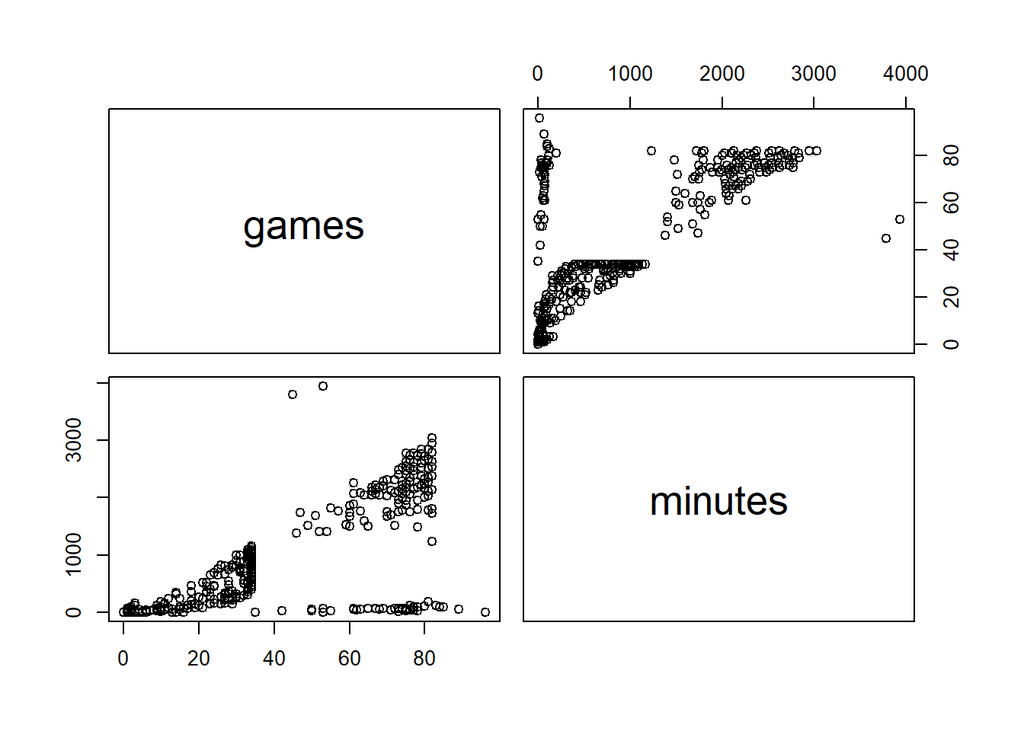

```r
t_nba_reduced<-t_nba[,-4:-10]
t_nba_reduced<-t_nba_reduced[,-1:-1]
pairs(t_nba_reduced)
```

- Entre el número de minutos jugados y los puntos la relación es lineal.

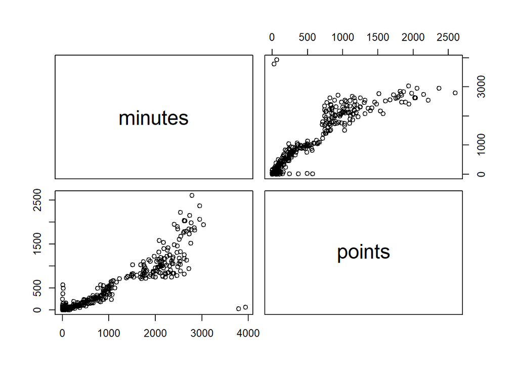

```r
t_nba_reduced<-t_nba[,-5:-10]
t_nba_reduced<-t_nba_reduced[,-1:-2]
pairs(t_nba_reduced)
```

Esto me lleva a pensar que los minutos son un atributo esencial, si un jugador no juega obviamente no va a tener oportunidad de conseguir ninguna estadistica.

Por otro lado, debemos tener en cuenta que tenemos dos origenes de datos distintos.

- Los jugadores de la NBA juegan un máximo de 82 partidos por temporada.
- Las jugadoras de la WNBA juegan un máximo de 34 partidos por temporada.

Por lo que los valores estadisticos totales discriminan a las jugadoras, que no tendran la misma cantidad de puntos, ni de rebotes.

Por lo que realizaremos los siguientes ajustes:

- Convertimos los atributos de estadisticas en tipo numérico.

```r
t_nba[2:9] <- lapply(t_nba[2:9], as.numeric)
```

```r
t_nba<-t_nba[which(t_nba$games!="0"),]
```

```r
games_m=82
games_w=34
for(i in 2:9) {
    t_nba[which(t_nba$sex=="0"),i] <- t_nba[which(t_nba$sex=="0"),i]/games_m
    t_nba[which(t_nba$sex=="1"),i] <- t_nba[which(t_nba$sex=="1"),i]/games_w
}
```

- Se elimina la columna de total de partidos.

```r
t_nba<-t_nba[,-2:-2]
```

- Eliminamos los registros de jugadores que no han jugado ningún minuto.

```r
t_nba<-t_nba[which(t_nba$minutes!="0"),]
```

- Eliminamos los registros de jugadores que tengan un número de minutos por partido que podamos catalogar como fringelier, es decir que se alejen 3 veces la desviación estandard de la media.
- Al haber eliminado los fringeliers habremos eliminado tambien los outliers.

```r
remove_outliers <- function(x, limit = 3) {
    mn <- mean(x, na.rm = T)
    out <- limit * sd(x, na.rm = T)
    x < (mn - out) | x > (mn + out)
}
t_nba<-t_nba[remove_outliers(t_nba$minutes,3)==FALSE,]
```

Vemos que con la definicion de fringelier no existen valores asociados a los minutos. Esto se debe a que la desviación estandard es lo bastante grande como para poder abarcar la practica totalidad de valores sin que se consideran fringeliers.

Veamos una representación mediante boxplot de las variables numéricas:

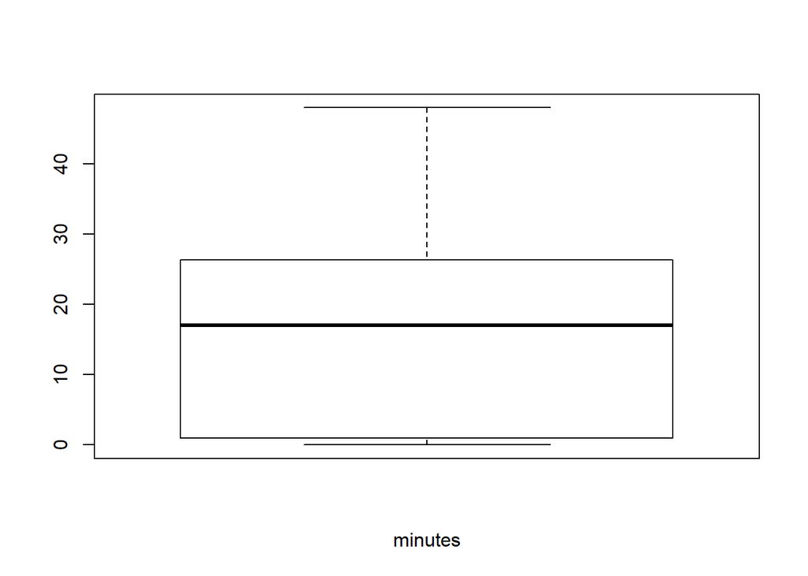

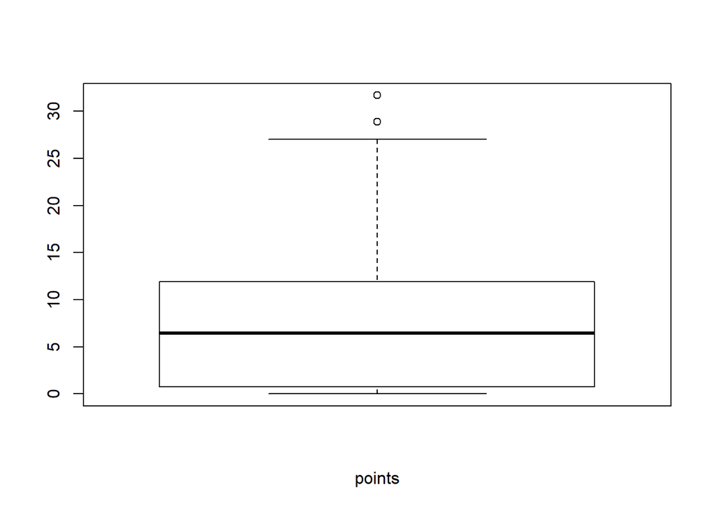

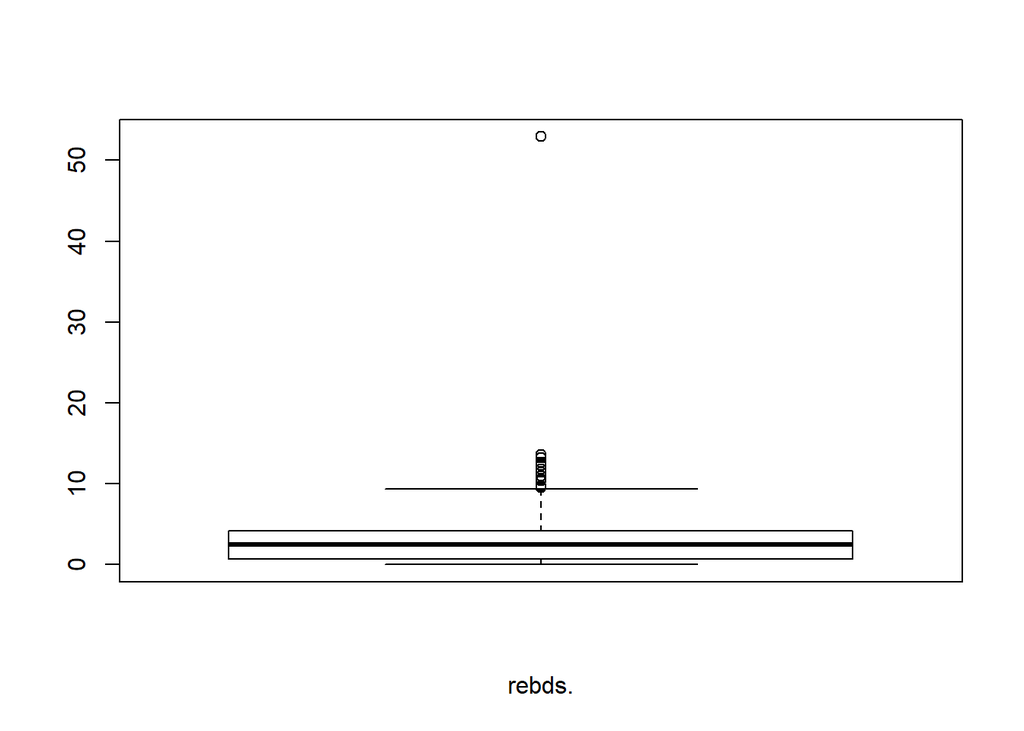

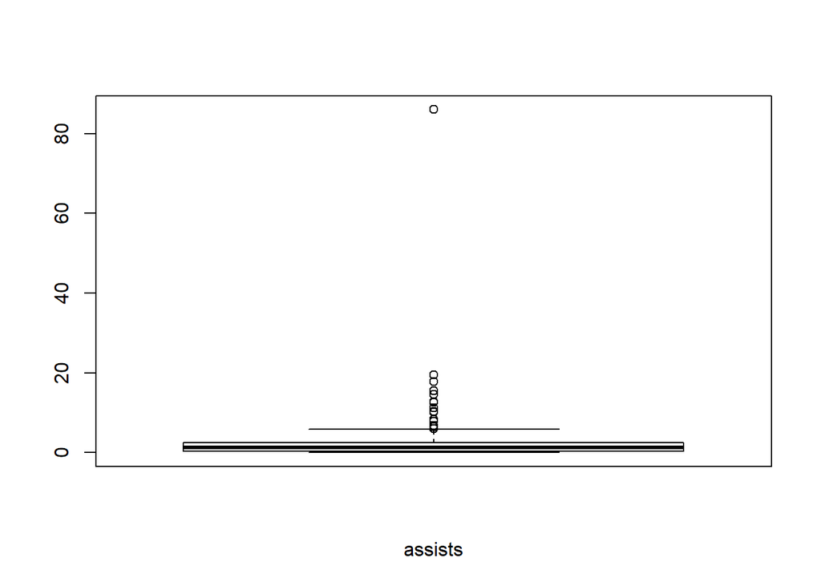

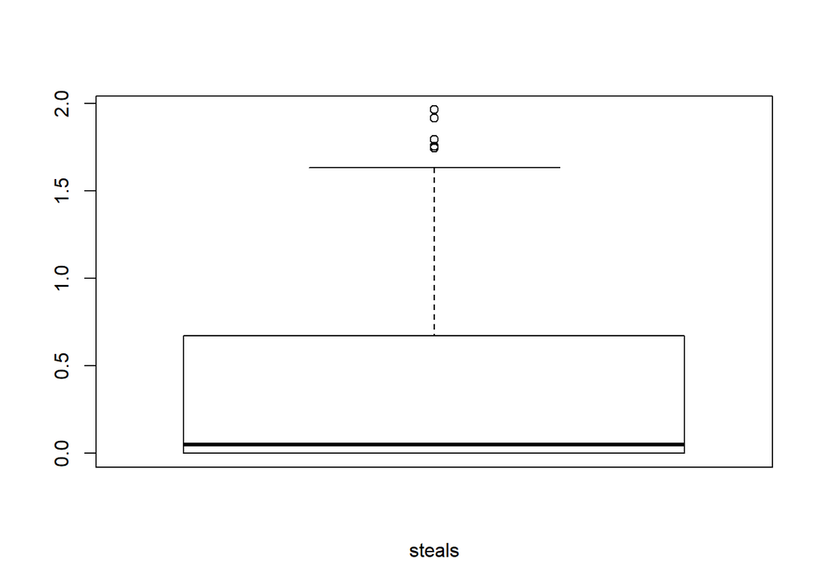

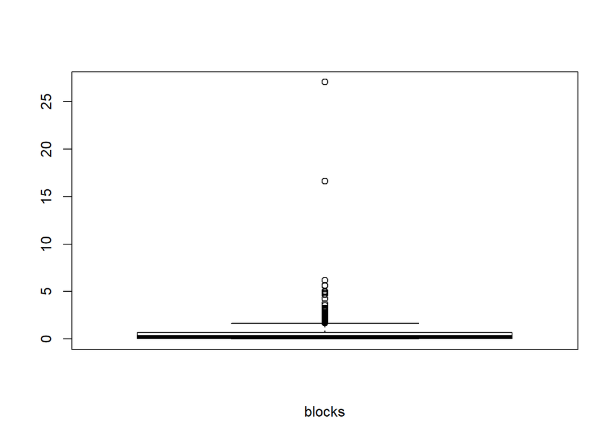

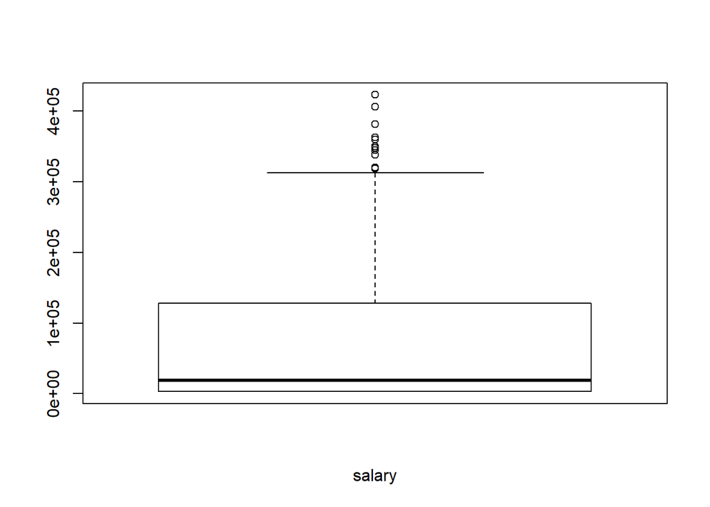

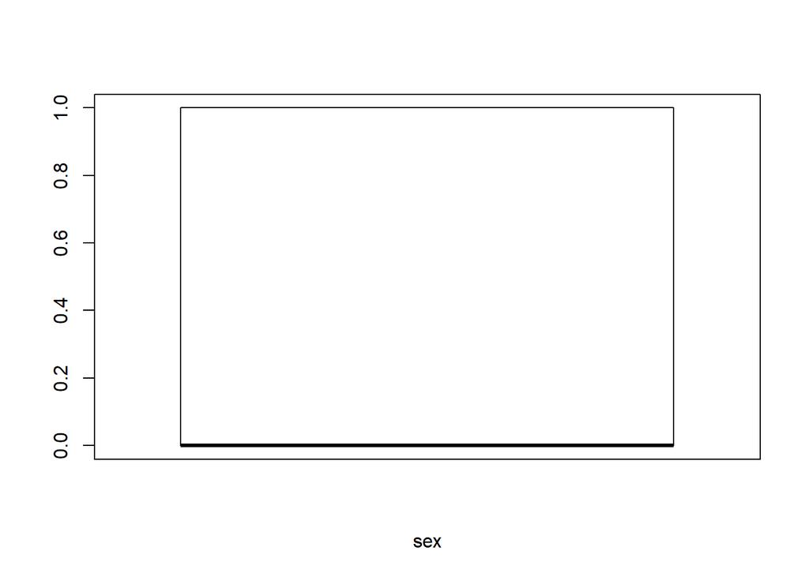

```r
for(i in 1:ncol(t_nba)) {
  if (is.numeric(t_nba[,i])){
    boxplot(t_nba[,i], xlab = colnames(t_nba)[i], width = 100)
  }
}
```

```r
t_nba
```

[output not shown]

[output cut: 801 more lines]